# Descriptive Statistics

Matthew Talluto

18.01.2021

# Populations & Samples

- A **population** is the unit about which we want to use statistics to describe, analyse, or perform inference.
  - e.g., all the trees in a forest

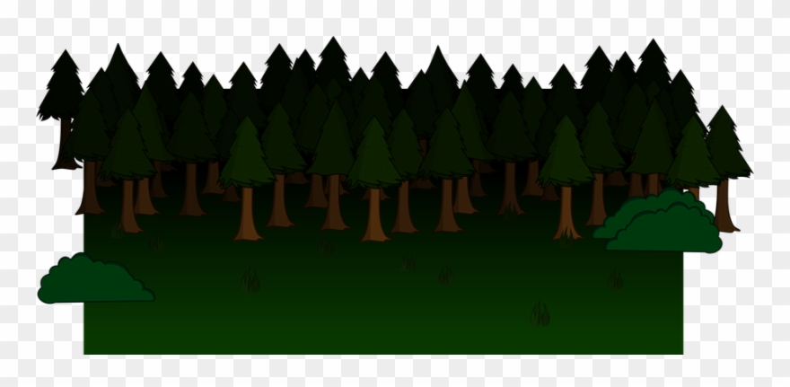

# Test

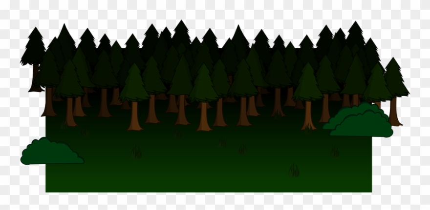

# Populations & Samples

- A **population** is the unit about which we want to use statistics to describe, analyse, or perform inference.
  - e.g., all the trees in a forest
- A **sample** is a subset of a population that is observed with the goal of obtaining knowledge about a population.

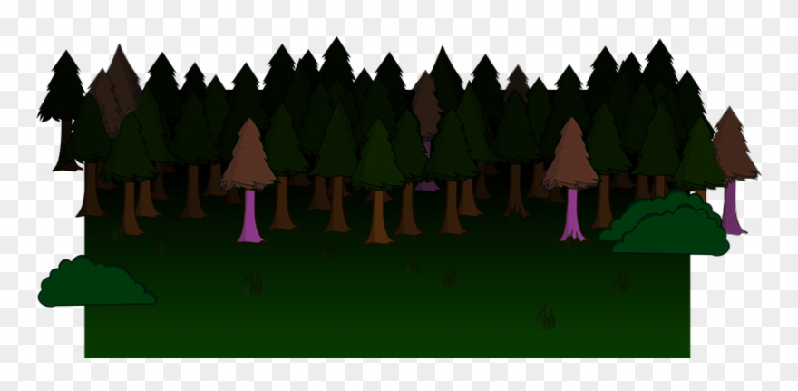

# Populations & Samples

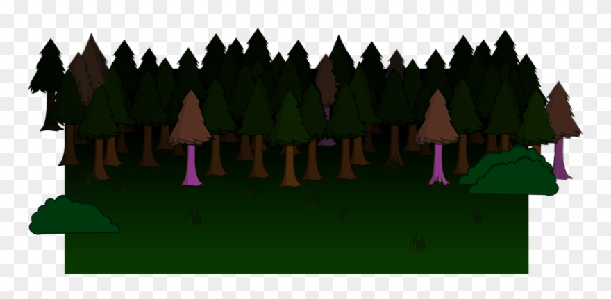

# Describing populations and samples

- We can visualise the distribution of values within a population using a **histogram**
- We use **summary statistics** to describe the values numerically.
- In practise, we must estimate population statistics via sample statistics.
- We can formally describe the shape of the distribution of values using special statistics called **moments**.

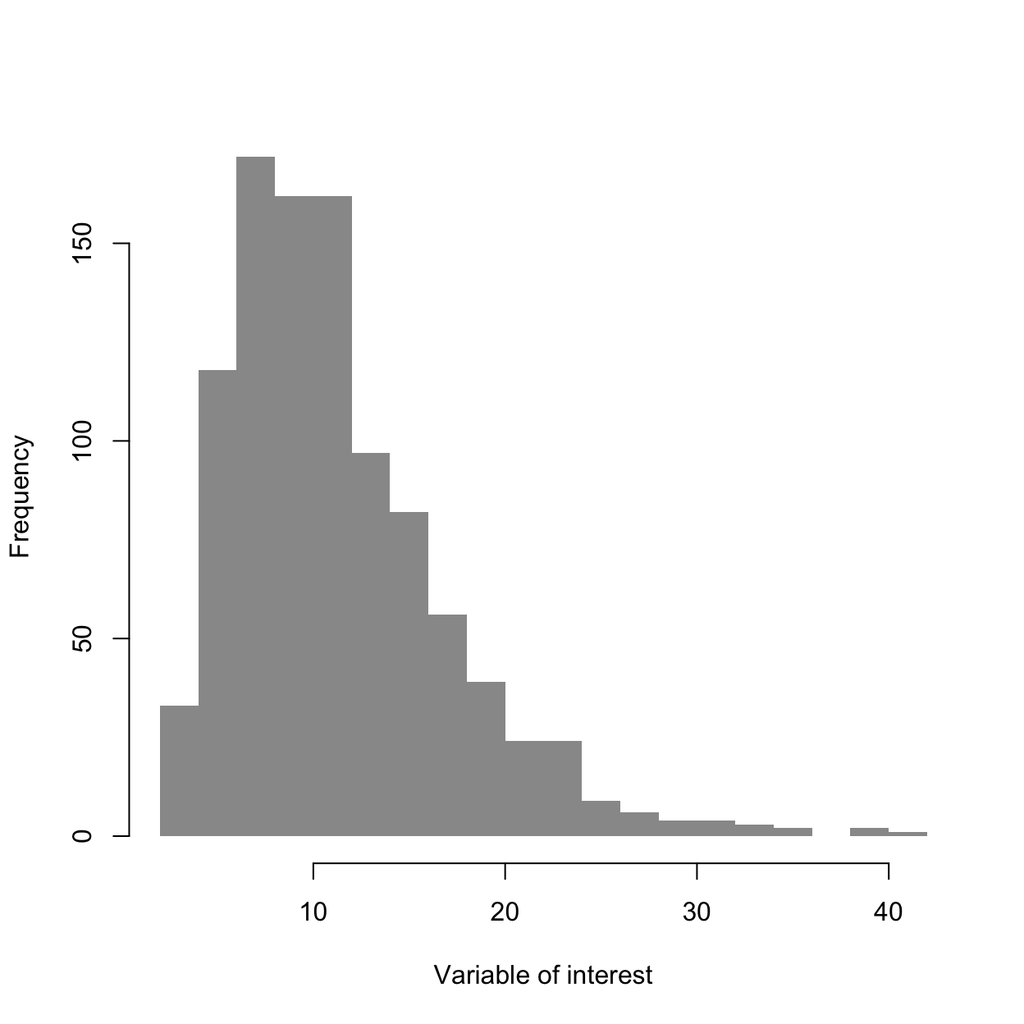

# Summary statistics: location

- **First moment**: Arithmetic mean.

The population mean ($\mu$) can be approximated with the **sample mean**:

$$\mu \approx \bar{x} = \frac{1}{n}\sum_{i=1}^n x_i$$

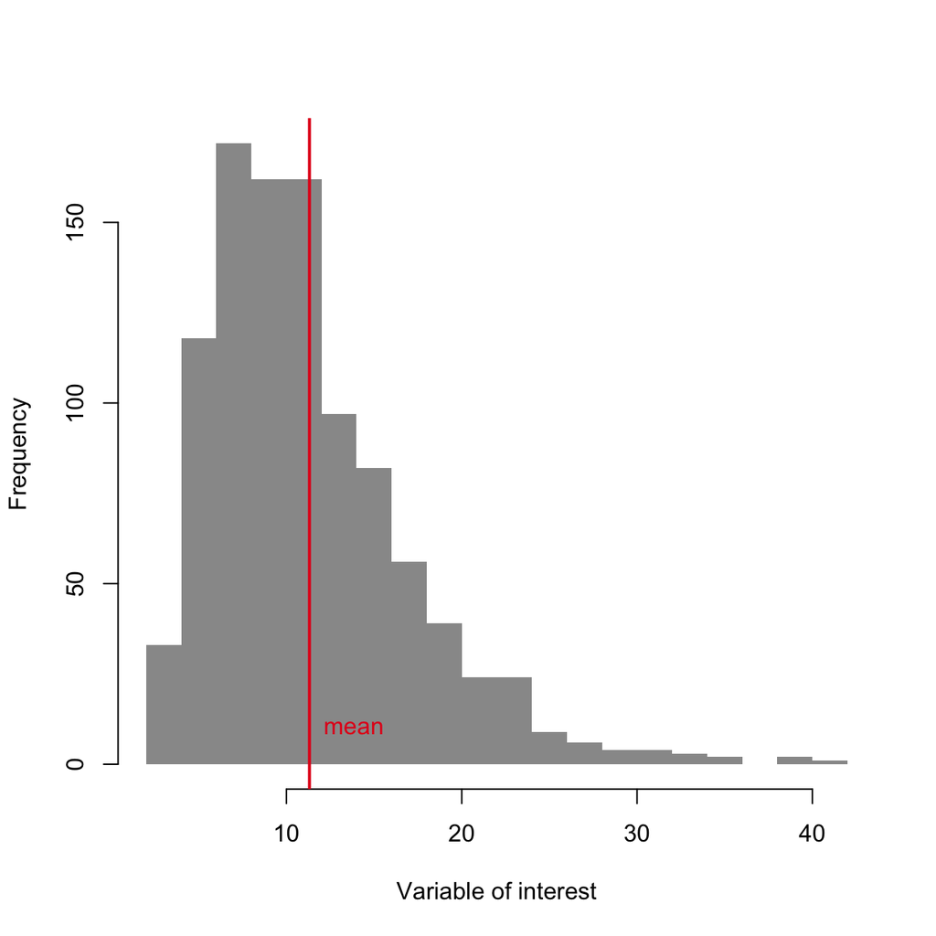

```r
mean(x)
```

```
## [1] 11.31501
```

# Summary statistics: location

- **First moment**: Arithmetic mean.

The population mean ($\mu$) can be approximated with the **sample mean**:

$$\mu \approx \bar{x} = \frac{1}{n}\sum_{i=1}^n x_i$$

### Other location statistics

The mean can be strongly influenced by outliers.

- median: The 50% quantile (i.e., half the values of x are above the median, half below)
- mode: the most common value, the “peak” of a distribution

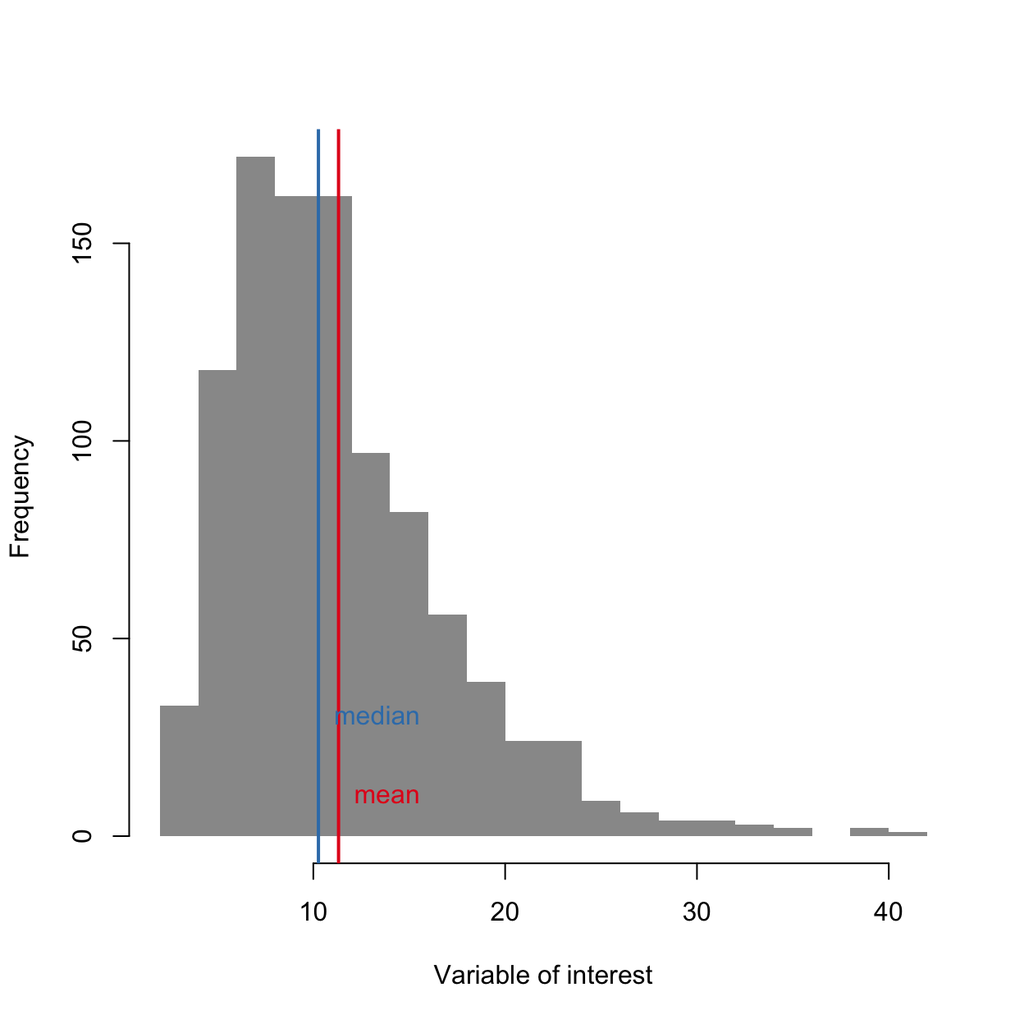

```r
median(x)
```

```
## [1] 10.26619
```

```r
## mode
mode(x) ## wrong!
```

```
## [1] "numeric"
## we can use the histogram function to approximate the sample mode
## changing the number of breaks will have a large impact on the results
```

```r
x_hist = hist(x, breaks = 20, plot = FALSE)
x_hist$mids[which.max(x_hist$density)]
```

```
## [1] 7
```

# Summary statistics: location

- **First moment**: Arithmetic mean.

The population mean ($\mu$) can be approximated with the **sample mean**:

$$\mu \approx \bar{x} = \frac{1}{n}\sum_{i=1}^n x_i$$

### Other location statistics

- minimum, maximum values
- quantiles: the p-th quantile of x is the value of x such that p% of values are beneath the quantile
  - commonly used: (2.5%, 97.5%), 50%, (25%, 75%)

### Comparing variables

We can compare variables in a way that is *location independent* by **centering** (subtracting the mean)

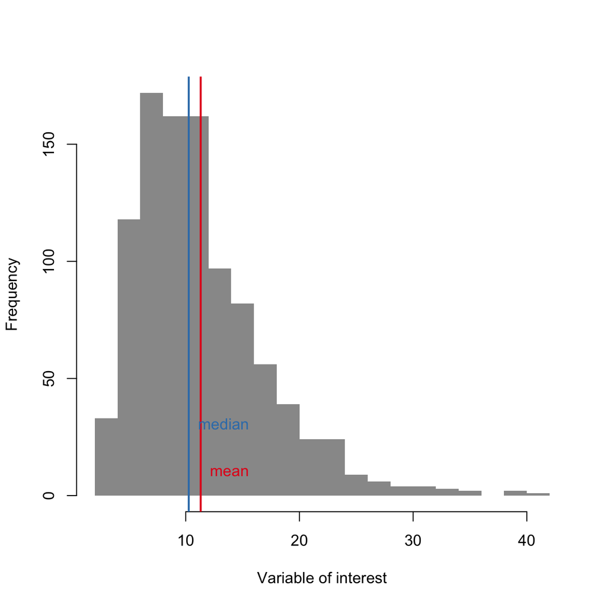

```r
c(min(x), max(x))
```

```
## [1]  2.08264 40.85426
```

```r
range(x)
```

```
## [1]  2.08264 40.85426
```

```r
quantile(x, 0.4)
```

```
##      40%
## 8.952672
```

```r
## Centre the variable
## note! arithmetic operators like `-` are vectorized!
x_ctr = x - mean(x)
mean(x_ctr)
```

```
## [1] -4.356771e-16
```

# Summary statistics: dispersion (or scale)

- **Second moment**: Variance ($\sigma^2$)

$$\sigma^2 = \frac{1}{N}\sum_{i=1}^N (X_i-\mu)^2$$

We can estimate $\sigma^2$ using the **sample variance**:

$$\sigma^2 \approx s^2 = \frac{1}{n-1}\sum_{i=1}^n (x_i -\bar{x})^2$$

It is convenient to talk about the scale of $x$ in the same units as $x$ itself, so we use the (population or sample) **standard deviation**:

$$\sigma = \sqrt{\sigma^2} \approx s = \sqrt{s^2}$$

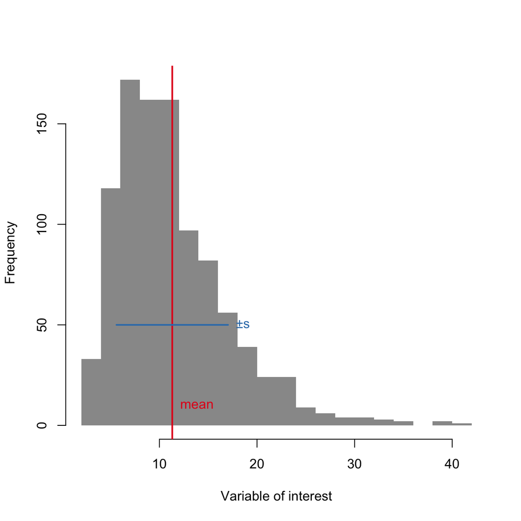

```r
# Population variance -- biased if x is a sample!
sum((x-mean(x))^2)/length(x)
```

```
## [1] 32.63556
```

```r
# These R functions always produce the sample variance and sd
var(x)
```

```
## [1] 32.66823
```

```r
sd(x)
```

```
## [1] 5.715613
```

# Summary statistics: dispersion (or scale)

### Other dispersion statistics

- range: `max(x) - min(x)`
- interquartile range (IQR): the difference between the third and first quartiles
- coefficient of variation (CV):
  $$\frac{s}{|\bar{x}|}$$

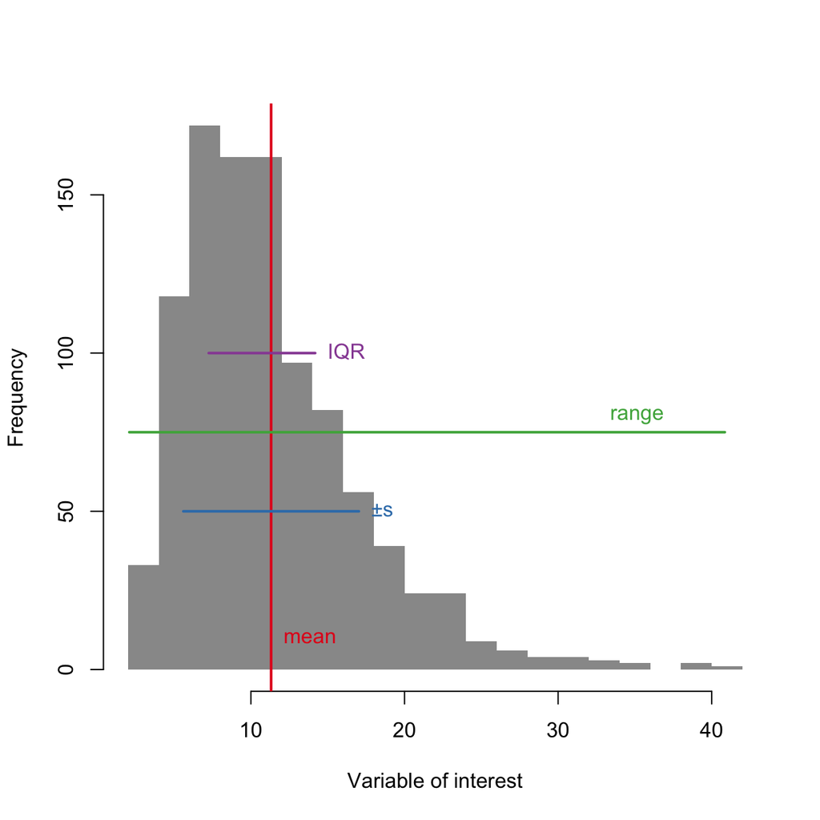

```r
# the range function gives you the min and max
## Take the difference to get the statistical range
diff(range(x))
```

```
## [1] 38.77162
```

```r
max(x) - min(x)
```

```
## [1] 38.77162
```

```r
IQR(x)
```

```
## [1] 6.933959
```

```r
quantile(x, 0.75) - quantile(x, 0.25)
```

```
##      75%
## 6.933959
```

```r
# coefficient of variation can be done manually
sd(x)/mean(x)
```

```
## [1] 0.5051353
```

# Summary statistics: higher moments

### Asymmetry: skewness

Is the distribution weighted to one side or the other?

$$\mathrm{skewness} = \frac{\sum_{i=1}^{n}(x_i-\bar{x})^3}{(n-1)s^3}$$

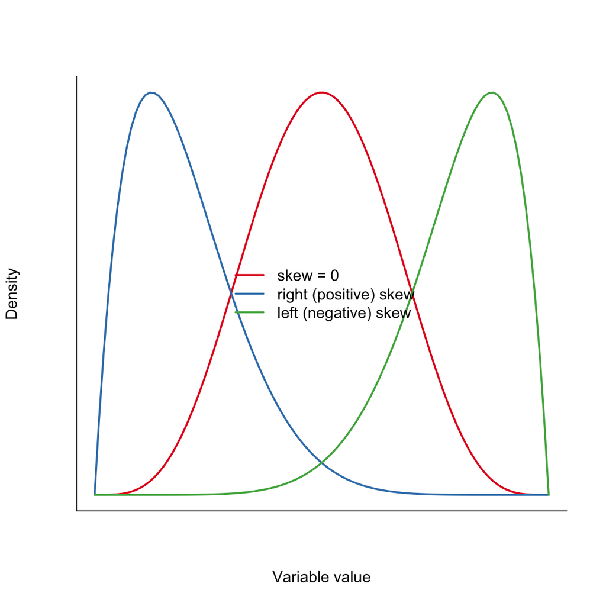

### Tailedness: kurtosis

How fat are the tails relative to a normal distribution?

$$\mathrm{kurtosis} = \frac{\sum_{i=1}^{n}(x_i-\bar{x})^4}{(n-1)s^4}$$

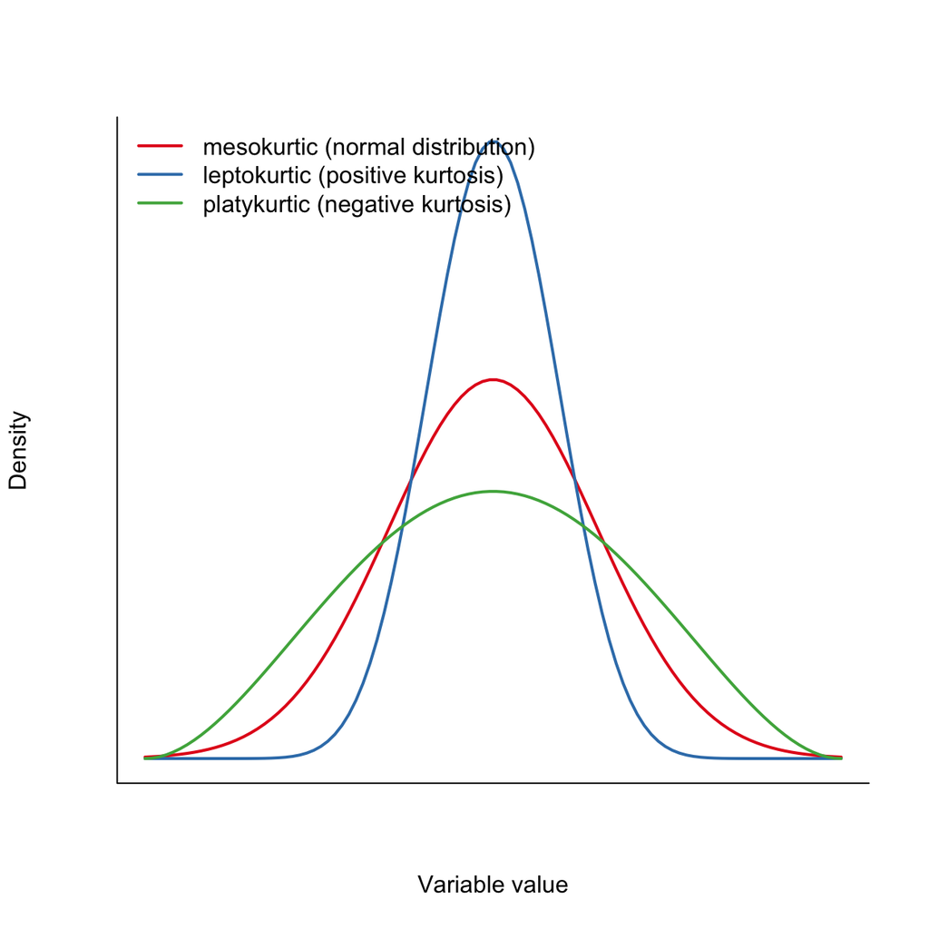

# Summarizing samples graphically: histograms

- A **histogram** reports the frequency (or density) of a sample on the y-axis, with the variable on the x-axis.
- Often the simplest view of the entire distribution of a dataset
- In R, we use the `hist` function
  - `col` changes the colour of the bars
  - `breaks` changes the number of bins, or specifies exactly where the breaks are
  - `main` gives the plot a title

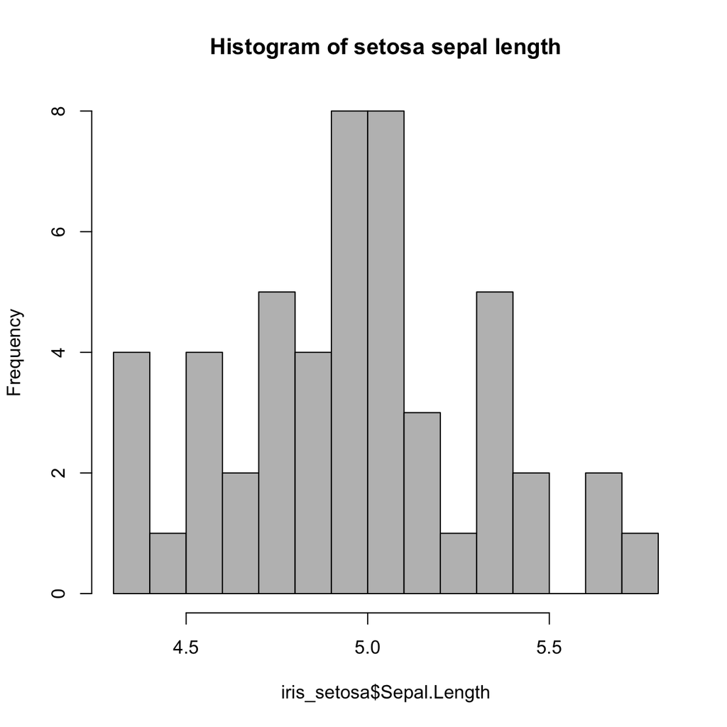

```r
data(iris)

## subset the data by a single species
iris_setosa = subset(iris, Species == "setosa")

## change the bin width and the title
hist(iris_setosa$Sepal.Length, breaks=20, col="gray", main="Histogram of setosa sepal length")
```

# Summarizing samples graphically: boxplots

- **Boxplots** (sometimes **box-and-whisker** diagrams) summarize key statistics.
- They are very useful for comparing variables.
- `y ~ group` is a special data type called a `formula`

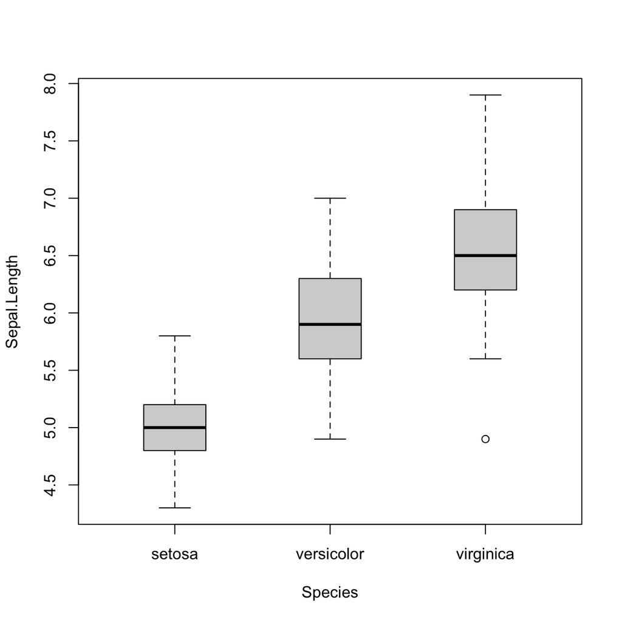

```r
boxplot(Sepal.Length ~ Species, data = iris)
```

# Summarizing samples graphically: boxplots

- **Boxplots** (sometimes **box-and-whisker** diagrams) summarize key statistics.
- They are very useful for comparing variables.
- `y ~ group` is a special data type called a `formula`

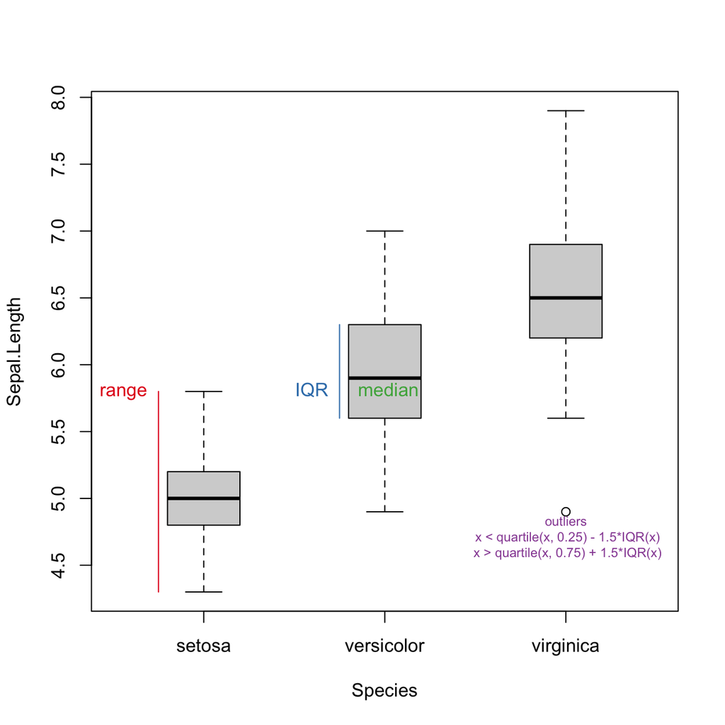

```r
boxplot(Sepal.Length ~ Species, data = iris)
```

# Programming in R: Repeating yourself

- An important programming concept is **DRY**: Don’t Repeat Yourself!
  - Don’t copy and paste code if you can instead instruct the computer to repeat things for you.
- There are many ways to execute the same code repeatedly; we will cover these in detail as they are needed.
- A motivating example:
  - Compute the mean of every variable in the `iris` dataset
  - Note that the last variable, `species`, is nominal and thus the mean is not defined

```r
## bad!
col_means = c(
  mean(iris[,1]),
  mean(iris[,2]),
  mean(iris[,3]),
  mean(iris[,1]),  # it's easy to introduce mistakes this way!
  mean(iris[,5]))
```

| Sepal.Length | Sepal.Width | Petal.Length | Petal.Width | Species |
| --- | --- | --- | --- | --- |
| 5.843 | 3.057 | 3.758 | 5.843 | NA |

# Programming in R: applying functions

- We want to **apply** the function named `mean` separately to every variable in `iris`
- R has many different ways to apply functions, in this case we use `s`imple `apply` (`sapply`)

```r
col_means = sapply(iris, mean) # apply the function mean to each variable in iris
col_means
```

|  | x |
| --- | --- |
| Sepal.Length | 5.843333 |
| Sepal.Width | 3.057333 |
| Petal.Length | 3.758000 |
| Petal.Width | 1.199333 |
| Species | NA |

# Programming in R: applying functions

- We want to **apply** the function named `mean` separately to every variable in `iris`
- R has many different ways to apply functions, in this case we use `s`imple `apply` (`sapply`)
- this works with any function that accepts a vector, even when they return more than a single value

```r
# we use only the first four columns, because these functions throw an error with non-numeric data
sapply(iris[,1:4], range)
```

| Sepal.Length | Sepal.Width | Petal.Length | Petal.Width |
| --- | --- | --- | --- |
| 4.3 | 2.0 | 1.0 | 0.1 |
| 7.9 | 4.4 | 6.9 | 2.5 |

```r
sapply(iris[,1:4], quantile, c(0.25, 0.5, 0.75))
```

|  | Sepal.Length | Sepal.Width | Petal.Length | Petal.Width |
| --- | --- | --- | --- | --- |
| 25% | 5.1 | 2.8 | 1.60 | 0.3 |
| 50% | 5.8 | 3.0 | 4.35 | 1.3 |
| 75% | 6.4 | 3.3 | 5.10 | 1.8 |

# Programming in R: applying functions to tabular data

- There are three species of iris; it makes more sense to have summary statistics for each one
- `tapply`: `t`abular `apply`
  - produces a summary table for a single variable (e.g., `Sepal.Length`) based on categories in another variable (e.g., `Species`)

```r
tapply(iris$Sepal.Length, iris$Species, mean)
```

```
##     setosa versicolor  virginica
##      5.006      5.936      6.588
```

# Programming in R: combining applys

- We can combine apply statements
- `tapply` works with a single variable,
- `sapply` can be used to run the same `tapply` on every variable
  - `sapply(X=iris,FUN=tapply,...)` where arguments for `tapply` replace `...`

```r
# this runs tapply on each of the four variables in iris
# it uses the Species variable to tabulate, then runs the mean function on each slice
mean_by_species = sapply(iris[,1:4], tapply, iris$Species, mean)
mean_by_species
```

|  | Sepal.Length | Sepal.Width | Petal.Length | Petal.Width |
| --- | --- | --- | --- | --- |
| setosa | 5.006 | 3.428 | 1.462 | 0.246 |
| versicolor | 5.936 | 2.770 | 4.260 | 1.326 |
| virginica | 6.588 | 2.974 | 5.552 | 2.026 |

# Probability distributions

**Thought experiment** You and 99 of your closest friends gather on the centre line of a football pitch. The pitch runs north-south, and is 100 m long. We will define the centre line as 0m, the northern boundary +50 m, and the southern boundary as -50 m.

Each person flips a fair coin. If the coin is heads, they take a step north (add 0.5 m to their location), if its tails, they take a step south (subtract 0.5 m from their location). Then we repeat this exercise 100 times (100 people, 100 coin flips each).

**Question**: What is the distribution of positions on the field?

# Probability distributions

**Thought experiment** You and 99 of your closest friends gather on the centre line of a football pitch. The pitch runs north-south, and is 100 m long. We will define the centre line as 0m, the northern boundary +50 m, and the southern boundary as -50 m.

Each person flips a fair coin. If the coin is heads, they take a step north (add 0.5 m to their location), if its tails, they take a step south (subtract 0.5 m from their location). Then we repeat this exercise 100 times (100 people, 100 coin flips each).

**Question**: What is the distribution of positions on the field?

We can simulate this experiment in R. Here is code for doing it for one person:

```r
position = 0
for(i in 1:100) {
  coin_flip = sample(c("heads", "tails"), 1)
  if(coin_flip == "heads") {
    position = position + 0.5
  } else {
    position = position - 0.5
  }
}
position
```

# Probability distributions

**Thought experiment** You and 99 of your closest friends gather on the centre line of a football pitch. The pitch runs north-south, and is 100 m long. We will define the centre line as 0m, the northern boundary +50 m, and the southern boundary as -50 m.

Each person flips a fair coin. If the coin is heads, they take a step north (add 0.5 m to their location), if its tails, they take a step south (subtract 0.5 m from their location). Then we repeat this exercise 100 times (100 people, 100 coin flips each).

**Question**: What is the distribution of positions on the field?

We can simulate this experiment in R.

And for a larger sample (2500) friends, doing more coin flips (500 each)

```r
positions = rep(0, 2500)
for(i in 1:500) {
  coin_flips = sample(c("heads", "tails"), length(positions), replace = TRUE)
  positions = positions + ifelse(coin_flips == "heads", 0.5, -0.5)
}
```

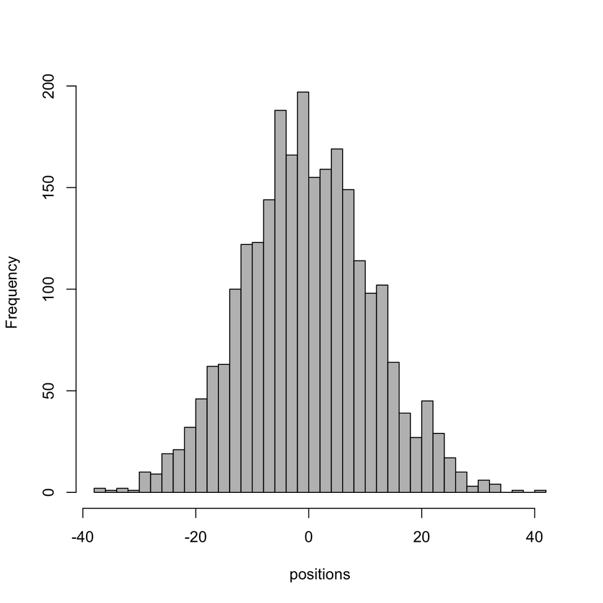

```r
hist(positions, breaks=40, col="gray", main="")
```

# Probability distributions: PDFs

- We can rescale this histogram, such that the **area** of each bar represents the proportion of samples within that bin.
- The height of each bar is the **probability density**.
- The figure approximates an empirical **probability density function**.

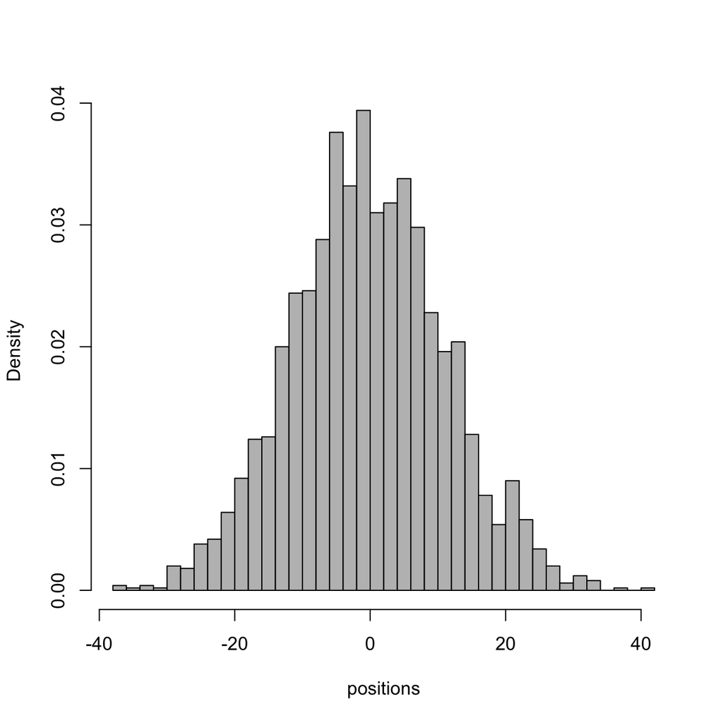

```r
hist(positions, breaks=40, col="gray", main = "", freq=FALSE)
```

# Probability distributions: PDFs

- We can rescale this histogram, such that the **area** of each bar represents the proportion of samples within that bin.
- The height of each bar is the **probability density**.
- The figure approximates an empirical **probability density function**.
- We can use the `density` function in R to add a curve approximating this density.

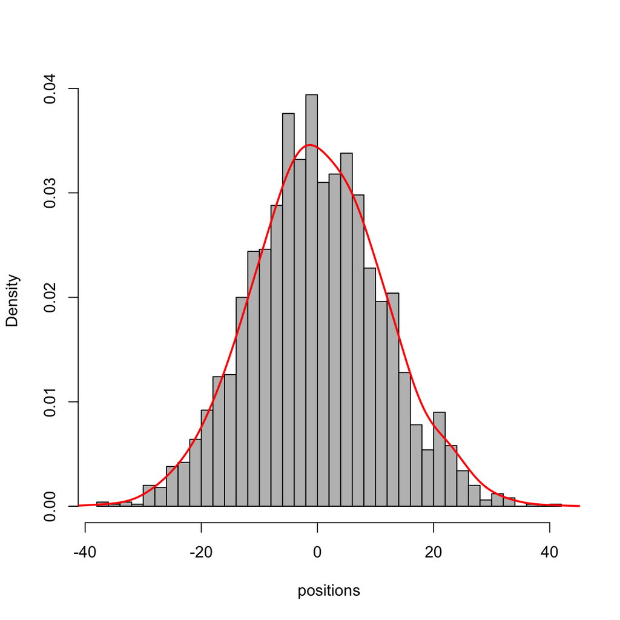

```r
hist(positions, breaks=40, col="gray", main = "", freq=FALSE)
lines(density(positions, adjust=1.5), col='red', lwd=2)
```

# Normal distributions

- This looks a lot like a normal distribution.
- As we take smaller and smaller steps, and do more coin flips, the distribution of values will converge exactly on a normal distribution.
- Here we add a normal **PDF** based on the sample mean and sd (in blue).

Side note: the curve produced by `density` works in two steps: First, it replaces each observation by a *small* normal **PDF** with the observation as its mean and some given standard deviation (the kernel size). Second, it sums up all those PDFs to get a smooth curve approximating the histogram.

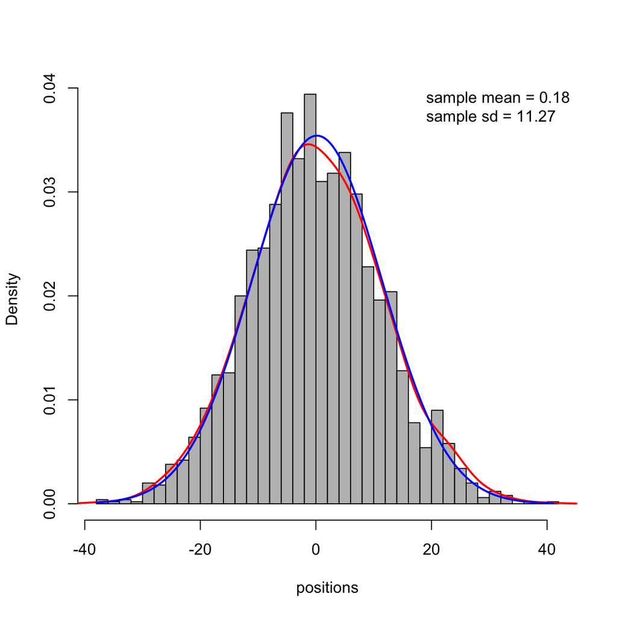

```r
hist(positions, breaks=40, col="gray", main = "", freq=FALSE)
lines(density(positions, adjust=1.5), col='red', lwd=2)
mu = mean(positions)
sig = sd(positions)
x_norm = seq(min(positions), max(positions), length.out = 400)
y_norm = dnorm(x_norm, mu, sig)
lines(x_norm, y_norm, lwd=2, col='blue')
legend("topright", legend=c(paste("sample mean =", round(mu, 2)),
                            paste("sample sd =", round(sig, 2))), lwd=0, bty='n')
```

# Normal distributions

# Normal distributions

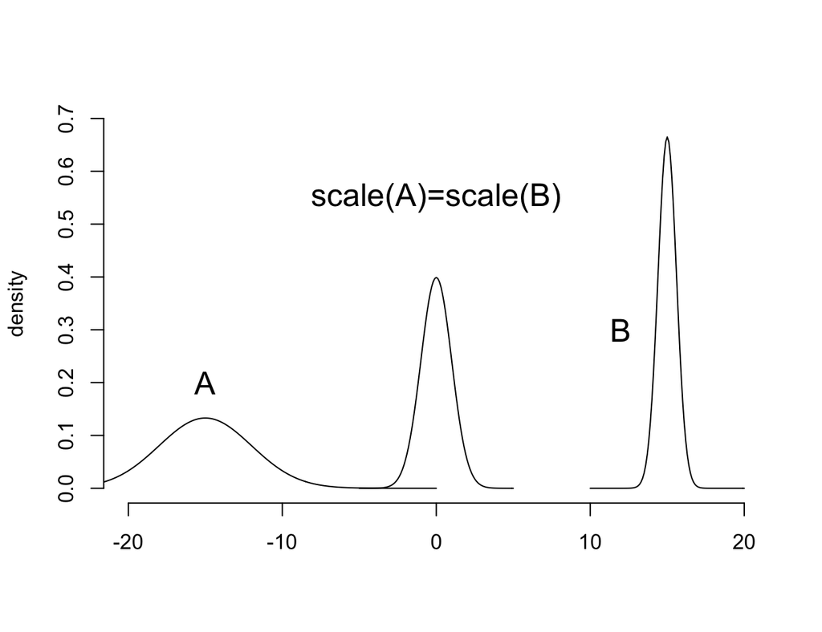

# Normal distributions

- The typical “bell-curve” shape of the normal distribution is the Normal **Probability Density Function** (PDF)

$$\mathcal{f}(x) = \frac{1}{\sigma \sqrt{2\pi}} \mathcal{e}^{-\frac{1}{2} \left (\frac{x-\mu}{\sigma} \right )^2}$$

- It is easiest to understand what this function represents by understanding its **integral**.
- Recall that the area of each bar in our histogram represents the *proportion* of observations in that bin.

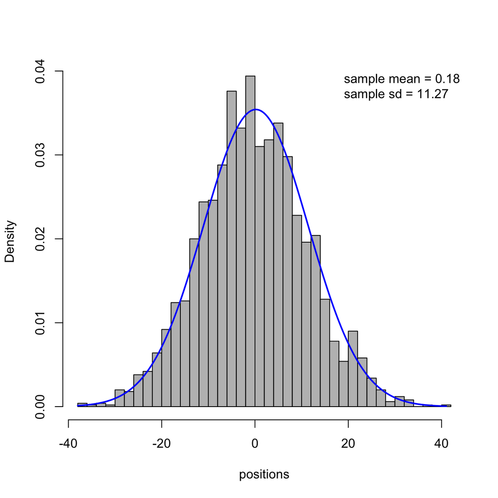

# Normal distributions: area under the curve

- The integral between two values $a$ and $b$ is equal to the area under the curve.
- This is exactly the probability of observing a value between $a$ and $b$.
- Rule of thumb: about 68% of values in any normal distribution will be within 1 standard deviation of the mean.

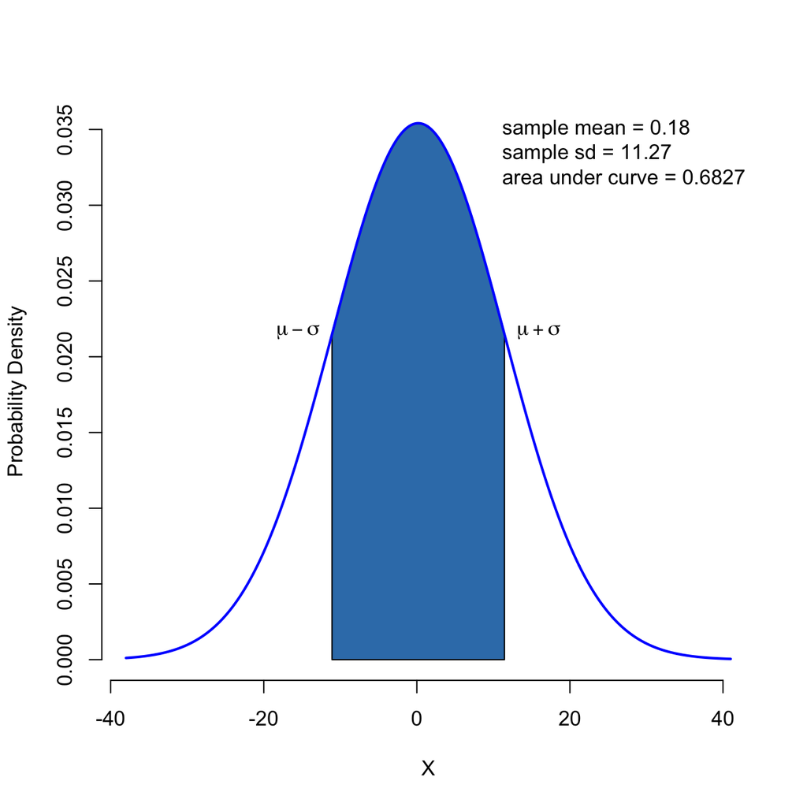

# Normal distributions: area under the curve

- The integral between two values $a$ and $b$ is equal to the area under the curve.
- This is exactly the probability of observing a value between $a$ and $b$.
- Rule of thumb: about 68% of values in any normal distribution will be within 1 standard deviation of the mean.
- Rule of thumb: 95% of values are $\mu \pm 1.96 \sigma \approx \mu \pm 2 \sigma$.

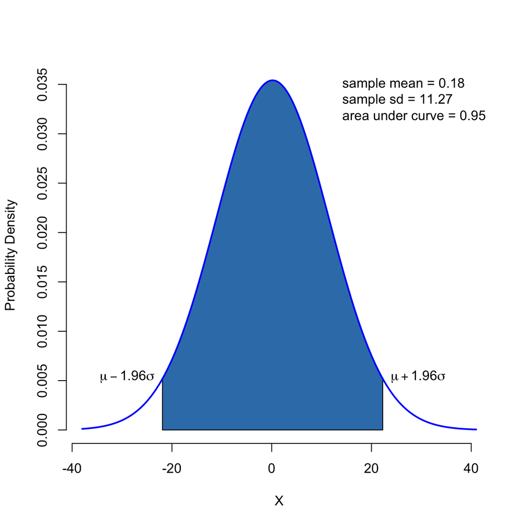

# Normal distributions: CDF

- If we integrate from $-\infty$ to some value $x$, then we have the probability of observing a value **less than** $x$.
- This integral of the Normal PDF is known as the Normal **cumulative distribution function**.

$$\mathcal{g}(x) = \int_{-\infty}^{x} \frac{1}{\sigma \sqrt{2\pi}} \mathcal{e}^{-\frac{1}{2} \left (\frac{x-\mu}{\sigma} \right )^2} dx$$

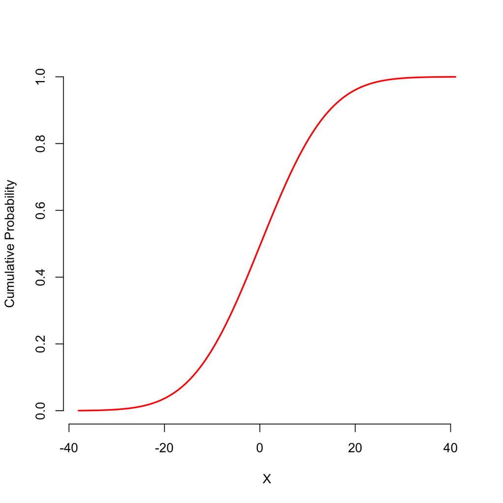

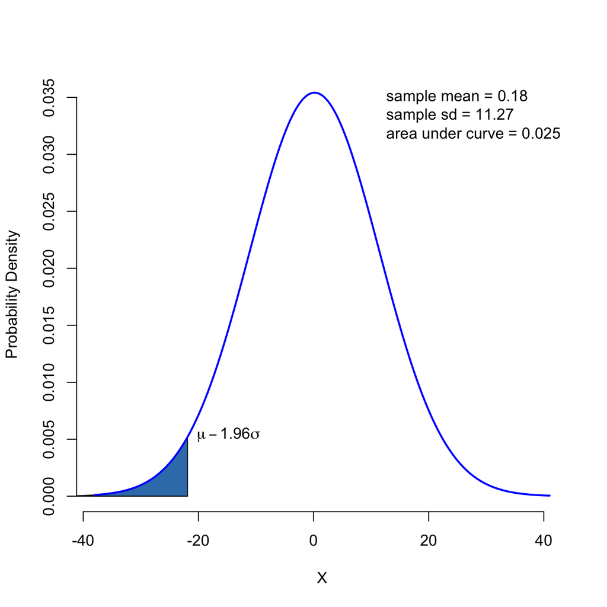

# Distributions in R

- R has four functions in common for many families of distributions:

**PDF**: what is the probability `d`ensity when $x=3$ (the height of the bell curve)

```r
dnorm(x = 3, mean = 0, sd = 1)
```

```
## [1] 0.004431848
```

**CDF**: what is the cumulative `p`robability when $x=q$

(area under the bell curve from $-\infty$ to $q$)

(probability of observing a value < $q$)

```r
pnorm(q = 3, mean = 0, sd = 1)
```

```
## [1] 0.9986501
```

**Quantiles**: what is the value of $x$, such that the probability of observing **x or smaller** is $p$

(inverse of the CDF)

```r
qnorm(p = 0.025, mean = 0, sd = 1)
```

```
## [1] -1.959964
```

**RNG**: Random number generator, produces $n$ random numbers from the desired distribution

```r
rnorm(n = 10, mean= 0, sd = 1)
```

```
##  [1]  0.6058991 -1.2295246 -1.0408264  0.3617239  1.7308747 -0.8545137
##  [7] -0.5786148  1.1398662  0.8516675  0.7108691
```

R supports many distributions, we will discuss others as they come up.

# Sampling error

- In practise, we work with samples, which are imperfectly representative of the populations from which they are drawn.
- The **sample mean** $(\bar{x})$ and **sample standard deviation** $(s)$ approximate the population $\mu$ and $\sigma$.
- We would like to known how good our estimates are!
- A **standard error** tells you how well a **sample statistic** represents the **population parameter**.
- If you repeat your sampling many times, and compute a separate sample statistic each time (e.g., $\bar{x}$, $s$, etc)…
- The sample statistics will converge on a normal distribution (if the sample size is large).
- The **standard deviation of sample statistics** will equal the **standard error** of the statistic.

# Standard error of the mean

- In practise, we work with samples, which are imperfectly representative of the populations from which they are drawn
- The **sample mean** $(\bar{x})$ and **sample standard deviation** $(s)$ approximate the population $\mu$ and $\sigma$
- We would like to known how good our estimates are!
- A **standard error** tells you how well a **sample statistic** represents the **population parameter**.
- If you repeat your sampling many times, and compute a separate sample statistic each time (e.g., $\bar{x}$, $s$, etc)…
- The sample statistics will converge on a normal distribution (if the sample size is large)
- The **standard deviation of sample statistics** will equal the **standard error** of the statistic.
- We commonly use the **standard error of the mean** to make inferences about the mean of a sample
- A larger sample size results in a smaller standard error

$$\sigma_{\bar{x}} = \frac{\sigma}{\sqrt{n}} \approx \frac{s}{\sqrt{n}}$$

# Central limit theorem

- If you repeat your sampling many times, and compute a separate sample statistic each time (e.g., $\bar{x}$, $s$, etc)…
- The sample statistics will converge on a normal distribution (if the sample size is large).
- This holds generally in many natural systems.
- If a variable $x$ is normally distributed, then $\bar{x}$ will be normally distributed, regardless of sample size.
- The farther $x$ is away from a normal distribution, the larger $n$ must be before $\bar{x}$ follows a normal distribution.
- If $n$ is large enough…
- $\bar{x}$ will be normally distributed with a mean = $\mu$ and standard deviation = the standard error of the mean.